# Evaluating hypothetical land consolidation decisions for smallholder farmers in Kenya

Hannah Kamau<sup>a,@</sup>, Cory Whitney<sup>a,b</sup> <sup>a</sup>Center of Development Research (ZEF), University of Bonn, Genscherallee 3, 53113 Bonn, Germany <sup>b</sup>INRES-Horticultural Sciences, University of Bonn, Auf dem Huegel 6, 53121 Bonn, Germany <sup>@</sup>Corresponding author’s email:hannah.nyakio@gmail.com

# Introduction

This document is a supplementary resource describing the land consolidation model used to simulate the outcomes of the decision to consolidate land in Kenya by smallholder farmers. The data are expert estimates collected in March 2024, after co-creating a conceptual model with stakeholders, supplemented with published literature where available and were unavailable other stakeholders not in in the workshop were contacted to discuss the estimates.

# Required packages

The core R packages are `decisionSupport` (Luedeling et al. 2025), `tidyverse` (Wickham 2023), and `ggplot2` (Wickham 2016).

# From conceptual model to a land consolidation function

The conceptual model, co-created with stakeholders, reflects the costs, benefits, and risks that could arise when shifting from small, highly diversified farms to a model where farmers consolidate their land under external management.

**Costs a farmer could incur under land consolidation**

- Planning costs (legal fees, knowledge acquisition, stationery, printing)
- Loss of natural assets, e.g. perennial plants such as trees
- Food costs no longer saved
- Household upkeep cost prior to the first payment
- Medical bills due to a reduced active lifestyle

**Benefits a farmer could gain under land consolidation**

- Lease income
- Saved production costs
- Alternative income from on- or off-farm activities
- Better childhood outcomes
- Social cohesion
- Saved medical bills related to land-use accidents/diseases

**Costs incurred by a farmer who remains in the current system (“do nothing”)**

- Planning costs (incurred whether or not the farmer changes)
- Medical bills related to land-use accidents/diseases and stress
- Production costs

**Benefits under the “do nothing” option**

- Land security (valued via trees)
- Annual crop yield
- Saved food costs

Both options face risks: farmers who shift face social risks from freed-up time, while those who do nothing face crop-related risks.

*Shifting to land consolidation is modeled over a 25-year period, during which the farmer can no longer farm the consolidated parcel but receives lease income commensurate with its size.*

The `land_consolidation_function` defines these costs, benefits, and risks for both options. The **decision** is the difference between the two options.

# Inputs, model function, and test variables

The input file which contains the variables and estimates –> `land_consolidation_input.csv`. Market scenario file based on value of information –> `market_scenario.csv` which is used later.

```r
input_path    <- "land_consolidation_input.csv"
base_estimate <- decisionSupport::estimate_read_csv(input_path, sep = ";")
input_table   <- read.csv(input_path, sep = ";")
```

```r
make_variables <- function(est, n = 1) {
  x <- decisionSupport::random(rho = est, n = n)
  for (i in colnames(x)) assign(i, as.numeric(x[1, i]), envir = .GlobalEnv)
}
make_variables(base_estimate)
```

```r
source("land_consolidation_function.R")
```

# Monte Carlo simulation

```r
mcSimulation_results <- decisionSupport::mcSimulation(
  estimate          = base_estimate,
  model_function    = land_consolidation_function,
  numberOfModelRuns = 1e2,
  functionSyntax    = "plainNames")
```

# Results

## Distribution of the outcomes

We present 2 key results:- (i) The distribution of the 2 decision options (i) land consolidation and (ii) maintain farms; and (ii) the distribution of decision do which is reflected by the difference of the options.

```r
# Assemble model inputs (x) and outputs (y), then express NPVs per hectare.
mc_output <- cbind(as.data.frame(mcSimulation_results$y),
                   as.data.frame(mcSimulation_results$x)) %>%
  mutate(NPV_per_ha          = benefit_lc_kes        / ha_per_hh,
         No_NPV_per_ha       = benefit_status_quo_kes / ha_per_hh,
         NPV_per_ha_decision = net_benefit_lc_kes     / ha_per_hh)

# Summary statistics (million KES).
summarised_stats <- mc_output %>%
  select(NPV_per_ha, No_NPV_per_ha, NPV_per_ha_decision) %>%
  summarise(across(everything(), list(
    min         = ~min(., na.rm = TRUE) / 1e6,
    q05         = ~quantile(., 0.05, na.rm = TRUE) / 1e6,
    median      = ~median(., na.rm = TRUE) / 1e6,
    q95         = ~quantile(., 0.95, na.rm = TRUE) / 1e6,
    max         = ~max(., na.rm = TRUE) / 1e6,
    pc_positive = ~mean(. > 0, na.rm = TRUE) * 100))) %>%
  pivot_longer(everything(),
               names_to = c("variable", "statistic"),
               names_pattern = "^(.*)_(.*)$", values_to = "value") %>%
  pivot_wider(names_from = statistic, values_from = value) %>%
  mutate(across(min:max, \(x) round(x, 2)))
summarised_stats
```

```
## # A tibble: 6 × 7
##   variable                    min    q05 median   q95   max positive
##   <chr>                     <dbl>  <dbl>  <dbl> <dbl> <dbl>    <dbl>
## 1 NPV_per_ha              -528.   -33.1    7.89  31.8  90.8       NA
## 2 NPV_per_ha_pc             NA     NA     NA     NA    NA         79
## 3 No_NPV_per_ha             -0.26   2.76  17.1   63.6 726.        NA
## 4 No_NPV_per_ha_pc          NA     NA     NA     NA    NA         99
## 5 NPV_per_ha_decision    -1254.   -89.8   -8.76  17.1  29.7       NA
## 6 NPV_per_ha_decision_pc    NA     NA     NA     NA    NA         33
```

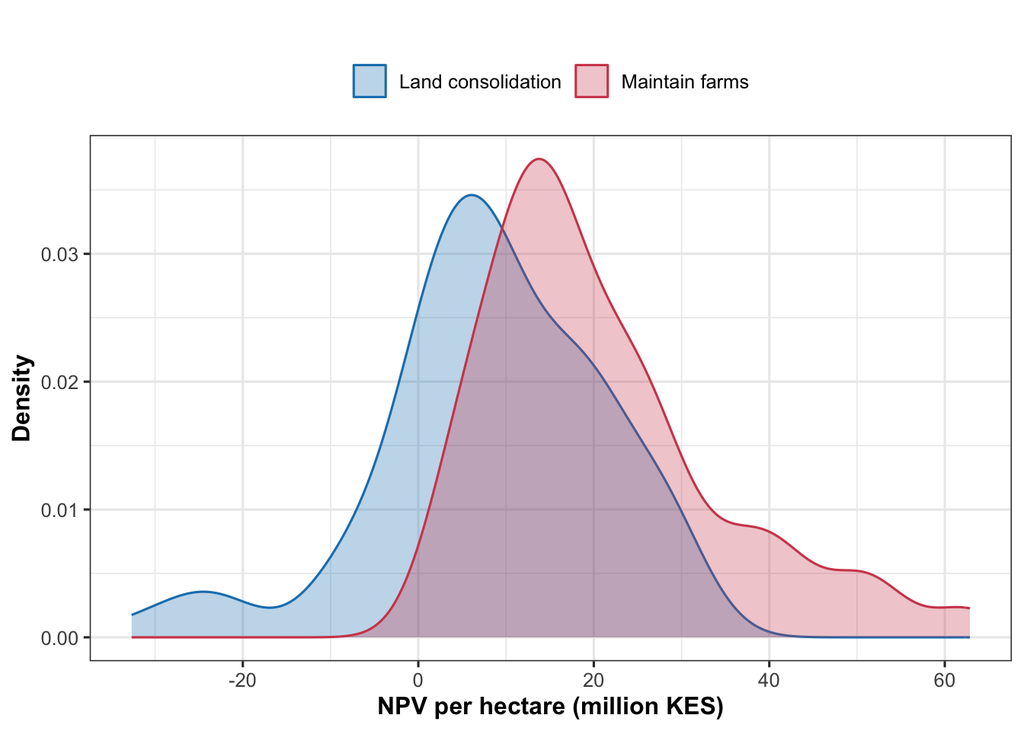

```r
# (a) Overlaid densities of the two options (trimmed to the 5-95% range).
mc_output %>%
  select(NPV_per_ha, No_NPV_per_ha) %>%
  pivot_longer(everything(), names_to = "variables", values_to = "project_outcome") %>%
  group_by(variables) %>%
  filter(project_outcome >= quantile(project_outcome, 0.05, na.rm = TRUE),
         project_outcome <= quantile(project_outcome, 0.95, na.rm = TRUE)) %>%
  ungroup() %>%
  mutate(variables = factor(variables, levels = c("NPV_per_ha", "No_NPV_per_ha"),
                            labels = c("Land consolidation", "Maintain farms"))) %>%
  ggplot(aes(project_outcome / 1e6, colour = variables, fill = variables)) +
  geom_density(alpha = 0.3) +
  scale_colour_manual(values = pal_decision) +
  scale_fill_manual(values = pal_decision) +
  labs(x = "NPV per hectare (million KES)", y = "Density", title = "") + #Overall outcomes
  theme_lc +
  theme(legend.position = "top")
```

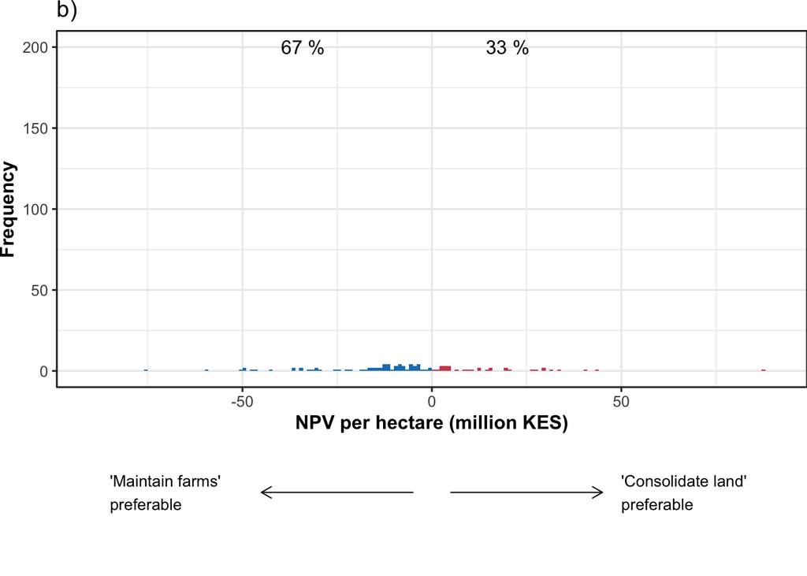

```r
# (b) The decision (net benefit), coloured by sign, with directional guidance.
percentages <- mc_output %>%
  summarise(negative = mean(net_benefit_lc_kes < 0,  na.rm = TRUE) * 100,
            positive = mean(net_benefit_lc_kes >= 0, na.rm = TRUE) * 100)
negative_percent <- round(percentages$negative, 2)
positive_percent <- round(percentages$positive, 2)

 mc_output %>%
  mutate(outcome_category = ifelse(net_benefit_lc_kes >= 0, "positive", "negative")) %>%
  ggplot(aes(net_benefit_lc_kes / 1e6, fill = outcome_category)) +
  geom_histogram(breaks = seq(-90, 90, by = 1)) +
  scale_fill_manual(values = c(negative = "#1a80bb", positive = "#d1495b")) +
  guides(fill = "none") +
  annotate("text", label = paste0(negative_percent, " %"), x = -34, y = 200) +
  annotate("text", label = paste0(positive_percent, " %"), x =  20, y = 200) +
  labs(x = "NPV per hectare (million KES)", y = "Frequency",
       title = "b)") + # Decision outcome for land consolidation
  theme_lc +
  theme(plot.margin = margin(0, 0, 90, 0)) +
  coord_cartesian(clip = "off") +
  annotation_custom(linesGrob(arrow = arrow(length = unit(0.25, "cm"), type = "open"),
                              gp = gpar(col = "black")),
                    xmin = 5, xmax = 45, ymin = -75, ymax = -75) +
  annotation_custom(textGrob("'Consolidate land'\npreferable", x = unit(0.8, "npc"),
                             y = unit(-0.1, "npc"), just = "left", gp = gpar(fontsize = 10)),
                    xmin = 50, xmax = 50, ymin = -75, ymax = -75) +
  annotation_custom(linesGrob(x = unit(c(1, 0), "npc"),
                              arrow = arrow(length = unit(0.25, "cm"), type = "open"),
                              gp = gpar(col = "black")),
                    xmin = -5, xmax = -45, ymin = -75, ymax = -75) +
  annotation_custom(textGrob("'Maintain farms'\npreferable", x = unit(0.8, "npc"),
                             y = unit(-0.1, "npc"), just = "left", gp = gpar(fontsize = 10)),
                    xmin = -85, xmax = -85, ymin = -75, ymax = -75)
```

## Variable importance and Expected Value of Perfect Information

We use variable in projection (VIP) to show important variables in the model and value of information is visualized using the expected value of perfect information (EVPI).

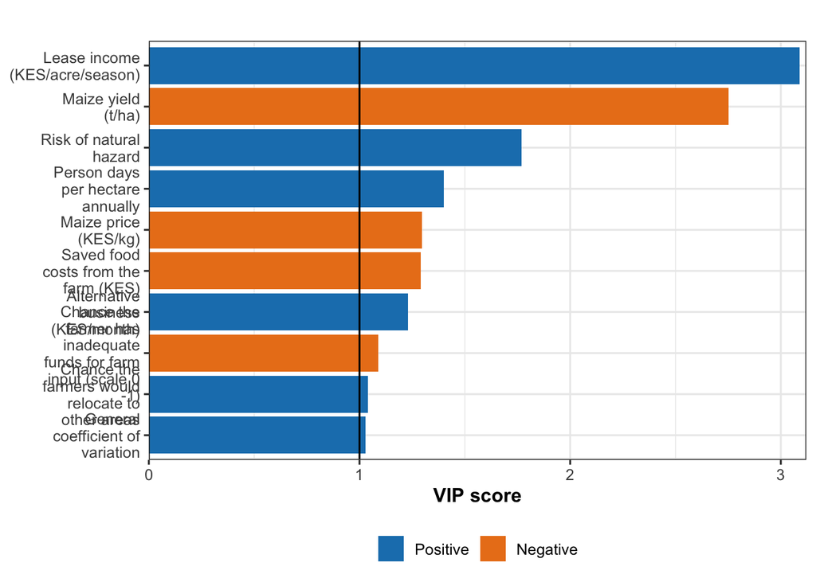

```r
pls_result <- plsr.mcSimulation(object = mcSimulation_results,
                                resultName = names(mcSimulation_results$y[3]), ncomp = 1)
decisionSupport::plot_pls(
  pls_result, input_table = input_table, threshold = 1,
  pos_color = "#1a80bb", neg_color = "#ea801c",  x_axis_name = "VIP score",) +
  scale_y_discrete(labels = \(y) str_wrap(y, width = 15)) +
  labs(title = " ") + #Variable importance
  theme_lc + theme(legend.position = "bottom",
                   legend.title = element_blank())
```

```r
mcSimulation_table <- data.frame(mcSimulation_results$x, mcSimulation_results$y[1:3])
if (!exists("evpi")) {
  evpi <- decisionSupport::multi_EVPI(mc = mcSimulation_table, first_out_var = "benefit_lc_kes")
}
```

```
## [1] "Processing 3 output variables. This can take some time."
## [1] "Output variable 1 (benefit_lc_kes) completed."
## [1] "Output variable 2 (benefit_status_quo_kes) completed."
## [1] "Output variable 3 (net_benefit_lc_kes) completed."
```

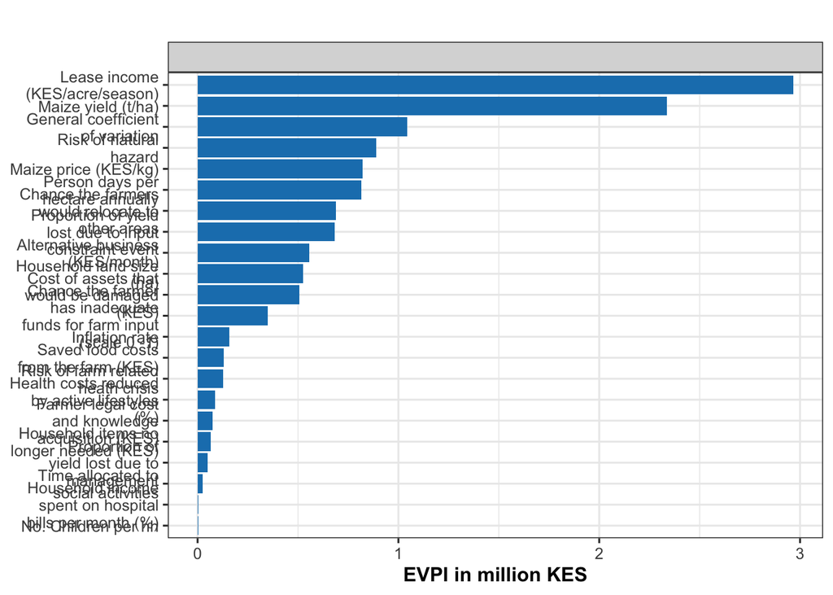

```r
plot_evpi(evpi, decision_vars = "net_benefit_lc_kes",
                   input_table = input_table, bar_color = "#1a80bb",
                   x_axis_name = "EVPI in million KES",
                   new_names = "") +
  scale_y_discrete(labels = \(y) str_wrap(y, width = 20)) +
  scale_x_continuous(labels = scales::label_number(scale = 1e-6)) +
  labs(title = "") + #Value of information
  theme_lc
```

# Monte Carlo simulation with scenarios

Requirements: price bounds for both maize and lease prices.

For maize-price bounds we obtained data from daily submissions to the Ministry of Agriculture (https://amis.co.ke/site/market). We used national level data and for Murang’a County that was available (2005–2024).

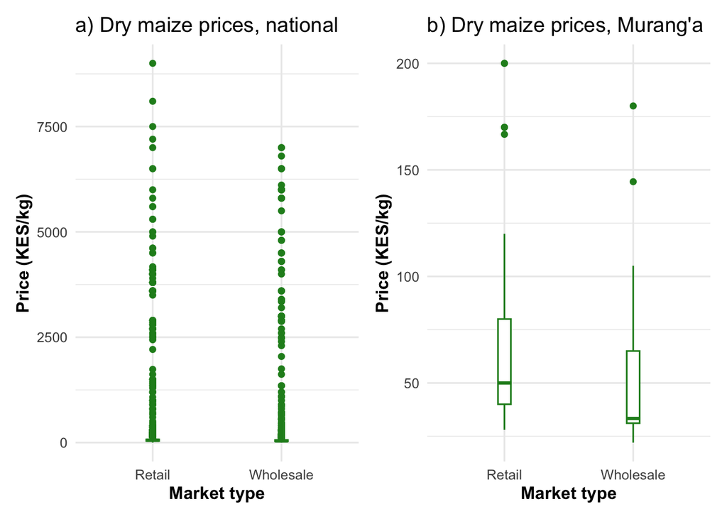

*Figure S1.* *Distribution of dry white maize prices in Kenya (a) and in Murang’a County (b).*

```r
# Read every maize-price CSV from the folder and clean the price columns.
maize_files <- list.files("maize_prices/", pattern = "\\.csv$", full.names = TRUE)

combined_df <- maize_files %>%
  map(\(f) read.csv(f, sep = ";") %>% mutate(Supply.Volume = as.numeric(Supply.Volume))) %>%
  list_rbind() %>%
  mutate(across(c(Wholesale, Retail),
                \(v) as.numeric(na_if(trimws(gsub("/Kg|,", "", v)), "-"))),
         Date = as.Date(Date))

price_boxplot <- function(df, title) {
  df %>%
    select(Wholesale, Retail) %>%
    pivot_longer(everything(), names_to = "market_type", values_to = "prices") %>%
    ggplot(aes(factor(market_type), prices)) +
    geom_boxplot(width = 0.1, colour = "forestgreen") +
    labs(x = "Market type", y = "Price (KES/kg)", title = title) +
    theme_minimal(base_size = 12) +
    theme(axis.title = element_text(face = "bold"))
}

 price_boxplot(combined_df, "a) Dry maize prices, national") +
         price_boxplot(filter(combined_df, County == "Muranga"), "b) Dry maize prices, Murang'a")
```

Maize prices have varied over time.

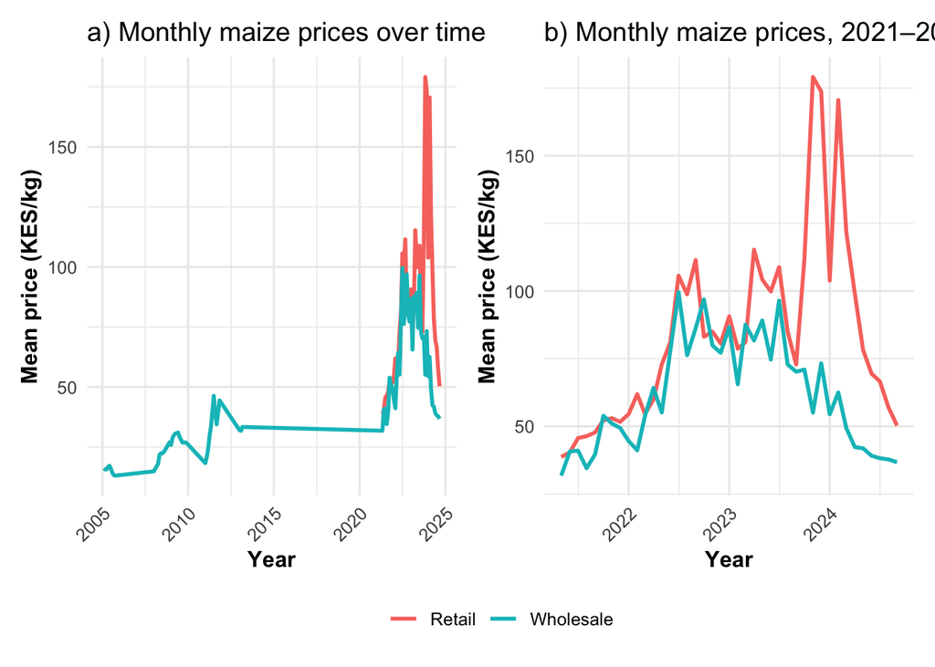

*Figure S2.* *Monthly mean maize prices (KES/kg) across the recorded markets: (a) the full series and (b) 2021–2024. Retail and wholesale prices are shown separately.*

```r
price_timeseries <- function(df, title) {
  df %>%
    mutate(month = as.Date(format(Date, "%Y-%m-01"))) %>%
    group_by(month) %>%
    summarise(Retail    = mean(Retail,    na.rm = TRUE),
              Wholesale = mean(Wholesale, na.rm = TRUE),
              .groups   = "drop") %>%
    pivot_longer(c(Retail, Wholesale), names_to = "Price type", values_to = "price") %>%
    ggplot(aes(month, price, colour = `Price type`)) +
    geom_line(linewidth = 1) +
    labs(x = "Year", y = "Mean price (KES/kg)", title = title, colour = NULL) +
    theme_minimal(base_size = 12) +
    theme(axis.title  = element_text(face = "bold"),
          axis.text.x = element_text(angle = 45, hjust = 1))
}

 price_timeseries(combined_df, "a) Monthly maize prices over time") +
         price_timeseries(
           filter(combined_df, Date >= as.Date("2021-01-01"),
                               Date <= as.Date("2024-12-31")),
           "b) Monthly maize prices, 2021–2024") +
         plot_layout(guides = "collect") &
         theme(legend.position = "bottom")
```

The `decisionSupport::scenario_mc` function updates specific variables from a scenario file. Our `market_scenarios.csv` updates maize and lease prices.

```r
scenarios  <- read.csv("market_scenarios.csv", sep = ";")
if (knitr::is_latex_output()) {
  scenarios %>%
    kbl(booktabs = TRUE, row.names = FALSE) %>%
    kable_styling(latex_options = c("striped", "scale_down"))
} else {
  scenarios %>%
    datatable(extensions = "Buttons", rownames = FALSE,
              options = list(dom = "Blfrtip", buttons = c("copy", "csv", "excel"),
                             scrollX = TRUE, autoWidth = TRUE))
}
```

| Variable | param | Scen_1 | Scen_2 | Scen_3 | Scen_4 | Scen_5 | Scen_6 | Scen_7 | Scen_8 | Scen_9 | Scen_10 | Scen_11 | Scen_12 | Scen_13 | Scen_14 | Scen_15 |
| --- | --- | --- | --- | --- | --- | --- | --- | --- | --- | --- | --- | --- | --- | --- | --- | --- |
| maize_price_kes_kg | lower | 5 | 86.68 | 168.34 |  |  |  | 5 | 5 | 5 | 86.68 | 86.68 | 86.68 | 168.34 | 168.34 | 168.34 |
| maize_price_kes_kg | upper | 86.67 | 168.33 | 250 |  |  |  | 86.67 | 86.67 | 86.67 | 168.33 | 168.33 | 168.33 | 250 | 250 | 250 |
| maize_price_kes_kg | distribution | posnorm | posnorm | posnorm | posnorm | posnorm | posnorm | posnorm | posnorm | posnorm | posnorm | posnorm | posnorm | posnorm | posnorm | posnorm |
| compensation_income_pm_acre | lower |  |  |  | 10000 | 340001 | 670001 | 10000 | 340001 | 670001 | 10000 | 340001 | 670001 | 10000 | 340001 | 670001 |
| compensation_income_pm_acre | upper |  |  |  | 340000 | 670000 | 1000000 | 340000 | 670000 | 1000000 | 340000 | 670000 | 1000000 | 340000 | 670000 | 1000000 |
| compensation_income_pm_acre | distribution |  |  |  | posnorm | posnorm | posnorm | posnorm | posnorm | posnorm | posnorm | posnorm | posnorm | posnorm | posnorm | posnorm |

```r
land_consolidation_scenarios <- scenario_mc(
  base_estimate     = base_estimate,
  scenarios         = scenarios,
  model_function    = land_consolidation_function,
  numberOfModelRuns = 1e2,
  functionSyntax    = "plainNames")
```